# Assignment 05

Neil Noyes

9/19/2020

## Problem 1

Load libraries

```r
library(tidyverse)
library(here)
```

Store path to dataset

```r
store_data_path <- here("Datasets", "msft.csv")
```

Read in data

```r
store_data <- read_csv(store_data_path)
```

Configure col_types (Price changed to col_number from col_character)

```r
store_data <- read_csv(store_data_path,
                        col_types = cols(
                                          Name = col_character(),
                                          Rating = col_double(),
                                          `No of people Rated` = col_double(),
                                          Category = col_character(),
                                          Date = col_character(),
                                          Price = col_number()
                                        )
                       )
```

And take a look

```r
str(store_data)
```

```
## tibble [5,322 × 6] (S3: spec_tbl_df/tbl_df/tbl/data.frame)
##  $ Name              : chr [1:5322] "Dynamic Reader" "Chemistry, Organic Chemistry and Biochemistry-simpleNeasyApp by WAGmob" "BookViewer" "Brick Instructions" ...
##  $ Rating            : num [1:5322] 3.5 3 3.5 3.5 2 4.5 4.5 3 4 3.5 ...
##  $ No of people Rated: num [1:5322] 268 627 593 684 634 399 566 175 460 363 ...
##  $ Category          : chr [1:5322] "Books" "Books" "Books" "Books" ...
##  $ Date              : chr [1:5322] "07-01-2014" "08-01-2014" "29-02-2016" "30-01-2018" ...
##  $ Price             : num [1:5322] NA NA NA NA NA NA NA NA NA NA ...
##  - attr(*, "problems")= tibble [5,163 × 5] (S3: tbl_df/tbl/data.frame)
##   ..$ row     : int [1:5163] 1 2 3 4 5 6 7 8 9 10 ...
##   ..$ col     : chr [1:5163] "Price" "Price" "Price" "Price" ...
##   ..$ expected: chr [1:5163] "a number" "a number" "a number" "a number" ...
##   ..$ actual  : chr [1:5163] "Free" "Free" "Free" "Free" ...
##   ..$ file    : chr [1:5163] "'/Users/hoggard/Google Drive/Classes/Fall 20/DSCI 301/Student submissions/A05/neil-noyes/DSCI301-F20-A05/Datasets/msft.csv'" "'/Users/hoggard/Google Drive/Classes/Fall 20/DSCI 301/Student submissions/A05/neil-noyes/DSCI301-F20-A05/Datasets/msft.csv'" "'/Users/hoggard…
##  - attr(*, "spec")=
##   .. cols(
##   ..   Name = col_character(),
##   ..   Rating = col_double(),
##   ..   `No of people Rated` = col_double(),
##   ..   Category = col_character(),
##   ..   Date = col_character(),
##   ..   Price = col_number()
##   .. )
```

We see that the string “Free” is used for price for free applications, which then leads to the column being read as NA as a parse error, so we will replace these with 0.0’s

```r
store_data <- store_data %>%
  mutate(
    Price = ifelse(is.na(Price),
                    0.0,
                    Price
    )
  )
```

Did you double check that *all* the NAs are as a result of the “Free” string, or are there any other causes?

Now we see the change

```r
str(store_data)
```

```
## tibble [5,322 × 6] (S3: spec_tbl_df/tbl_df/tbl/data.frame)
##  $ Name              : chr [1:5322] "Dynamic Reader" "Chemistry, Organic Chemistry and Biochemistry-simpleNeasyApp by WAGmob" "BookViewer" "Brick Instructions" ...
##  $ Rating            : num [1:5322] 3.5 3 3.5 3.5 2 4.5 4.5 3 4 3.5 ...
##  $ No of people Rated: num [1:5322] 268 627 593 684 634 399 566 175 460 363 ...
##  $ Category          : chr [1:5322] "Books" "Books" "Books" "Books" ...
##  $ Date              : chr [1:5322] "07-01-2014" "08-01-2014" "29-02-2016" "30-01-2018" ...
##  $ Price             : num [1:5322] 0 0 0 0 0 0 0 0 0 0 ...
##  - attr(*, "problems")= tibble [5,163 × 5] (S3: tbl_df/tbl/data.frame)
##   ..$ row     : int [1:5163] 1 2 3 4 5 6 7 8 9 10 ...
##   ..$ col     : chr [1:5163] "Price" "Price" "Price" "Price" ...
##   ..$ expected: chr [1:5163] "a number" "a number" "a number" "a number" ...
##   ..$ actual  : chr [1:5163] "Free" "Free" "Free" "Free" ...
##   ..$ file    : chr [1:5163] "'/Users/hoggard/Google Drive/Classes/Fall 20/DSCI 301/Student submissions/A05/neil-noyes/DSCI301-F20-A05/Datasets/msft.csv'" "'/Users/hoggard/Google Drive/Classes/Fall 20/DSCI 301/Student submissions/A05/neil-noyes/DSCI301-F20-A05/Datasets/msft.csv'" "'/Users/hoggard…
##  - attr(*, "spec")=
##   .. cols(
##   ..   Name = col_character(),
##   ..   Rating = col_double(),
##   ..   `No of people Rated` = col_double(),
##   ..   Category = col_character(),
##   ..   Date = col_character(),
##   ..   Price = col_number()
##   .. )
```

## Problem 2

If we look at one variable…

We can take a look at the distribution of ratings for apps on the Windows store:

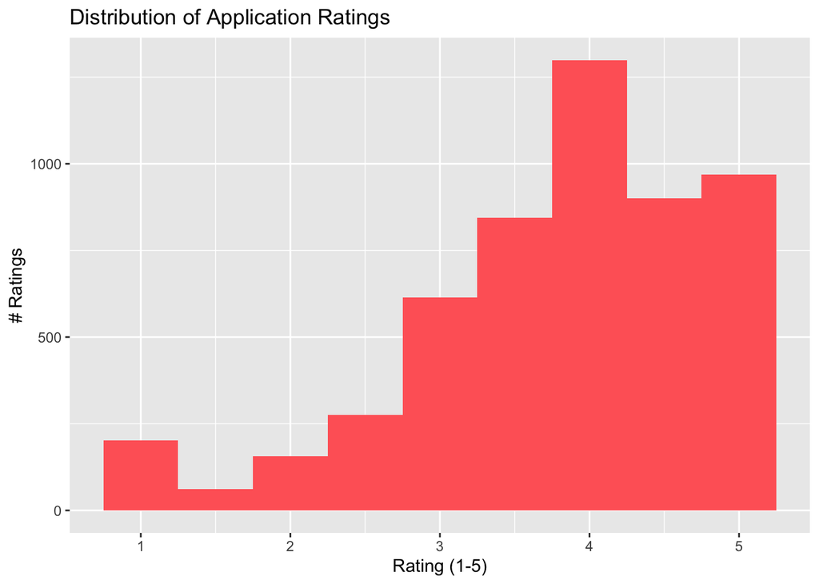

```r
store_data %>%
  ggplot() +
  geom_bar(aes(x = Rating), width = 0.5, fill = "#FF6666") +
  ggtitle("Distribution of Application Ratings") +
  xlab("Rating (1-5)") +
  ylab("# Ratings")
```

We see here that most ratings in the Windows store are fairly positive.

I’m not so sure about setting the width here. This lead to think this was a histogram, and that the ratings were more continuous.

## Problem 3

Now with two variables…

Lets look at the average rating per category!

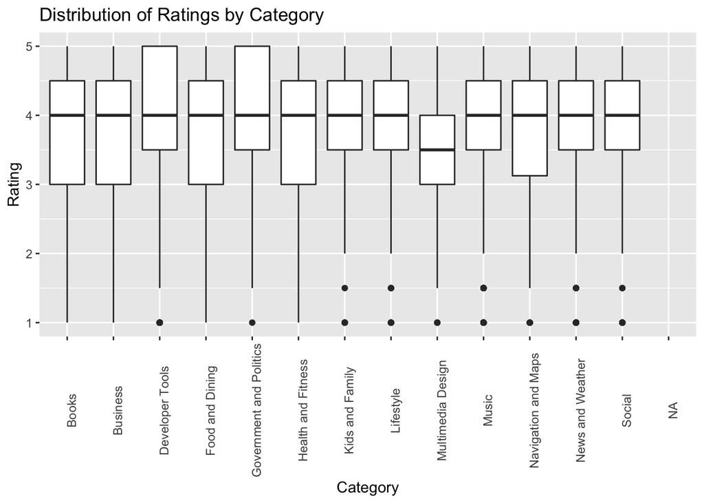

```r
store_data %>%
  ggplot() +
  geom_boxplot(aes(x = Category, y = Rating)) +
  theme(axis.text.x = element_text(angle = 90)) +
  ggtitle("Distribution of Ratings by Category")
```

Here we see a solid average of 4 stars for every category except multimedia design.. I guess those people have bad apps.

Interesting. Although there’s some differences in variability for some catgories.